# 永豐銀行Ｒ語言課程

January 29, 2016

## 用Ｒ實作決策樹－名人堂票選

## 名人堂票選

[figure not shown]

## 工具一覽

- `mosaic` 資料清理使用，裡面也使用了 `dplyr`。
- `Lahman` 包含了從 1871 年開始直到 2014 年的（2015 待更新）美國職棒大聯盟（MLB）各項數據。
- `rpart` 決策樹套件。
- `maptree` / `rpart.plot` 決策樹繪製。

```r
# install.packages("mosaic")
# install.packages("Lahman")
# install.packages("rpart")
# install.packages("maptree")
# install.packages("rpart.plot")
library(mosaic); library(Lahman); library(rpart); library(maptree); library(rpart.plot)
```

## 決策樹作為分類器

[figure not shown]

- 作為一個模型 `model`，分類器 `classifier` 是根據一些二元的變量 `binary response variable`，將資料不斷地分割 `partition`，使得每個分支下都是更相近、更「純」的子集 `subset`。
- 以今天的案例來說，我們的二元變數就是：「是否有被選進過名人堂？」

## 資料取得：分類用的依據 `binary response variable`

- 在 `Lahman` 資料集裡面，有提供 `HallOfFame` 的資料。

```r
inductees <-
  HallOfFame %>%
  group_by(playerID) %>%
  filter(votedBy %in% c("BBWAA", "Special Election") & category == "Player") %>%
  summarise(yearsOnBallot = n(), inducted = sum(inducted == "Y"), best = max(votes/ballots)) %>%
  arrange(desc(best))
head(inductees)
```

```
## Source: local data frame [6 x 4]
##
##    playerID yearsOnBallot inducted      best
##       (chr)         (int)    (int)     (dbl)
## 1 seaveto01             1        1 0.9883721
## 2  ryanno01             1        1 0.9879276
## 3 ripkeca01             1        1 0.9853211
## 4  cobbty01             1        1 0.9823009
## 5 brettge01             1        1 0.9818913
## 6 aaronha01             1        1 0.9783133
```

## 資料取得：訓練資料 `training data`

- 為了訓練我們的模型，需要定義我們的解釋變數。
- 首先是打擊數據
- 為了簡化，我們只參考安打數以及全壘打數。

```r
batting <-
  Batting %>% group_by(playerID) %>%
  summarise(numSeasons = length(unique(yearID)), lastSeason = max(yearID), tH = sum(H), tHR = sum(HR)) %>%
  arrange(desc(tH))
head(batting)
```

```
## Source: local data frame [6 x 5]
##
##    playerID numSeasons lastSeason    tH   tHR
##       (chr)      (int)      (int) (int) (int)
## 1  rosepe01         24       1986  4256   160
## 2  cobbty01         24       1928  4189   117
## 3 aaronha01         23       1976  3771   755
## 4 musiast01         22       1963  3630   475
## 5 speaktr01         22       1928  3514   117
## 6 jeterde01         20       2014  3465   260
```

## 資料取得：訓練資料 `training data`

- 為了訓練我們的模型，需要定義我們的解釋變數。
- 接著是投球數據
- 為了簡化，我們只參考勝場數、三振數以及救援成功數。

```r
pitching <-
  Pitching %>% group_by(playerID) %>%
  summarise(numSeasons = length(unique(yearID)), lastSeason = max(yearID), tW = sum(W), tSO = sum(SO), tSV = sum(SV)) %>%
  arrange(desc(tW))
head(pitching)
```

```
## Source: local data frame [6 x 6]
##
##    playerID numSeasons lastSeason    tW   tSO   tSV
##       (chr)      (int)      (int) (int) (int) (int)
## 1 youngcy01         22       1911   511  2803    17
## 2 johnswa01         21       1927   417  3509    34
## 3 alexape01         20       1930   373  2198    32
## 4 mathech01         17       1916   373  2502    28
## 5 galvipu01         15       1892   364  1806     2
## 6 spahnwa01         21       1965   363  2583    29
```

## 資料取得：訓練資料 `training data`

- 為了訓練我們的模型，需要定義我們的解釋變數。
- 最後是各項聯盟獎項的數據
- 為了簡化，我們只參考ＭＶＰ、賽揚獎以及金手套獎。

```r
awards <-
  AwardsPlayers %>% group_by(playerID) %>%
  summarise(mvp = sum(awardID == "Most Valuable Player"), gg = sum(awardID == "Gold Glove"), cy = sum(awardID == "Cy Young Award"))
head(awards, 2)
```

```
## Source: local data frame [2 x 4]
##
##    playerID   mvp    gg    cy
##       (chr) (int) (int) (int)
## 1 aaronha01     1     3     0
## 2 abbotji01     0     0     0
```

## 資料取得：訓練資料 `training data`

```r
candidates = merge(x=batting, y=pitching, by="playerID", all=TRUE)
candidates = merge(x=candidates, y=awards, by="playerID", all.x=TRUE)
candidates = merge(x=candidates, y=inductees, by="playerID") # join
```

- 把這幾個資料合併成一個 `data.frame`，以球員 `playerID` 作為索引，每筆資料都是單一球員的生涯數據。
- 因為這裡我們只要考慮有進入過名人堂票選的選手，因此可以注意到第三行程式碼其實等於是直接做 `join`。

## 資料取得：訓練資料 `training data`

```r
head(candidates, 3)
```

```
##    playerID numSeasons.x lastSeason.x   tH tHR numSeasons.y lastSeason.y
## 1 aaronha01           23         1976 3771 755           NA           NA
## 2 abbotji01           10         1999   NA  NA           10         1999
## 3 adamsba01           19         1926  216   3           19         1926
##    tW  tSO tSV mvp gg cy yearsOnBallot inducted      best
## 1  NA   NA  NA   1  3  0             1        1 0.9783133
## 2  87  888   0   0  0  0             1        0 0.0251938
## 3 194 1036  15   0  0  0            14        0 0.1366460
```

- 資料裡面很多 `NA` 缺失值，因為把野手跟投手放在一起。

## 資料取得：訓練資料 `training data`

```r
candidates[is.na(candidates)] <- 0
head(candidates, 3)
```

```
##    playerID numSeasons.x lastSeason.x   tH tHR numSeasons.y lastSeason.y
## 1 aaronha01           23         1976 3771 755            0            0
## 2 abbotji01           10         1999    0   0           10         1999
## 3 adamsba01           19         1926  216   3           19         1926
##    tW  tSO tSV mvp gg cy yearsOnBallot inducted      best
## 1   0    0   0   1  3  0             1        1 0.9783133
## 2  87  888   0   0  0  0             1        0 0.0251938
## 3 194 1036  15   0  0  0            14        0 0.1366460
```

- 在這個場合下，我們直接補 `0`。

## 模型建構：`rpart`－Recursive PARTitioning

- 在 `rpart` 中利用 `formula` "~" 建構模型。

```r
library(rpart)
mod = rpart(as.factor(inducted) ~ tH + tHR + mvp + gg + tW + tSO + tSV + cy,
            data = candidates) # method = c("anova","poisson","class","exp")
mod$variable.importance
```

```
##        tH        tW       mvp       tSO       tHR        cy        gg
## 52.793307 32.157822 19.335014 17.615083 10.889410 10.425217  3.057658
##       tSV
##  2.596990
```

## 模型建構：`rpart`－Recursive PARTitioning

```r
head(mod$frame)
```

```
##       var    n   wt dev yval complexity ncompete nsurrogate     yval2.V1
## 1      tH 1096 1096 116    1 0.15517241        4          1   1.00000000
## 2      tW 1024 1024  71    1 0.10344828        4          3   1.00000000
## 4     mvp  990  990  48    1 0.05172414        4          0   1.00000000
## 8     mvp  976  976  38    1 0.01293103        4          2   1.00000000
## 16     tW  908  908  23    1 0.01293103        4          1   1.00000000
## 32 <leaf>  865  865  15    1 0.00000000        0          0   1.00000000
##        yval2.V2     yval2.V3     yval2.V4     yval2.V5 yval2.nodeprob
## 1  980.00000000 116.00000000   0.89416058   0.10583942     1.00000000
## 2  953.00000000  71.00000000   0.93066406   0.06933594     0.93430657
## 4  942.00000000  48.00000000   0.95151515   0.04848485     0.90328467
## 8  938.00000000  38.00000000   0.96106557   0.03893443     0.89051095
## 16 885.00000000  23.00000000   0.97466960   0.02533040     0.82846715
## 32 850.00000000  15.00000000   0.98265896   0.01734104     0.78923358
```

## 模型建構：`rpart`－Recursive PARTitioning

```r
mod
```

```
## n= 1096
##
## node), split, n, loss, yval, (yprob)
##       * denotes terminal node
##
##  1) root 1096 116 0 (0.89416058 0.10583942)
##    2) tH< 2578.5 1024  71 0 (0.93066406 0.06933594)
##      4) tW< 249 990  48 0 (0.95151515 0.04848485)
##        8) mvp< 1.5 976  38 0 (0.96106557 0.03893443)
##         16) mvp< 0.5 908  23 0 (0.97466960 0.02533040)
##           32) tW< 205.5 865  15 0 (0.98265896 0.01734104) *
##           33) tW>=205.5 43   8 0 (0.81395349 0.18604651)
##             66) cy< 0.5 36   3 0 (0.91666667 0.08333333) *
##             67) cy>=0.5 7   2 1 (0.28571429 0.71428571) *
##         17) mvp>=0.5 68  15 0 (0.77941176 0.22058824)
##           34) tSO< 1146 61  10 0 (0.83606557 0.16393443) *
##           35) tSO>=1146 7   2 1 (0.28571429 0.71428571) *
##        9) mvp>=1.5 14   4 1 (0.28571429 0.71428571) *
##      5) tW>=249 34  11 1 (0.32352941 0.67647059)
##       10) tSO< 2490 16   7 0 (0.56250000 0.43750000) *
##       11) tSO>=2490 18   2 1 (0.11111111 0.88888889) *
##    3) tH>=2578.5 72  27 1 (0.37500000 0.62500000)
##      6) tH< 2993.5 46  21 0 (0.54347826 0.45652174)
##       12) tHR< 405 34  11 0 (0.67647059 0.32352941) *
##       13) tHR>=405 12   2 1 (0.16666667 0.83333333) *
##      7) tH>=2993.5 26   2 1 (0.07692308 0.92307692) *
```

## 決策樹呈現：`graphic`

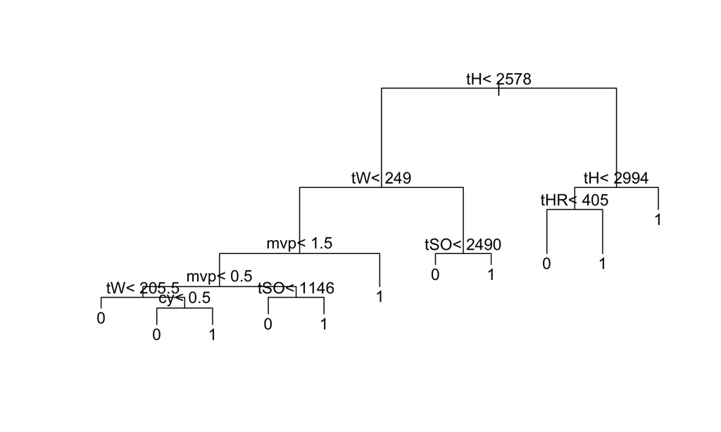

```r
par(xpd = TRUE); plot(mod); text(mod)
```

## 決策樹呈現：`maptree`

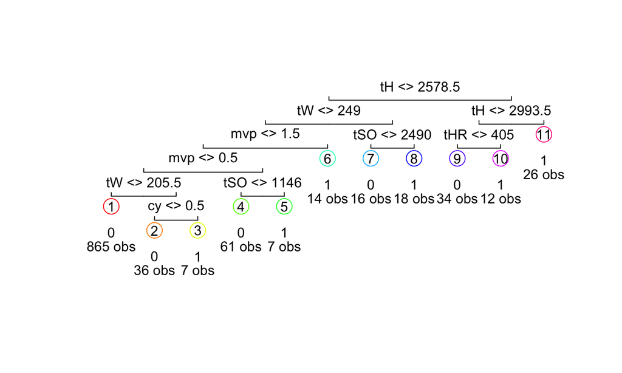

```r
library(maptree)
draw.tree(mod)
```

## 決策樹呈現：`rpart.plot`

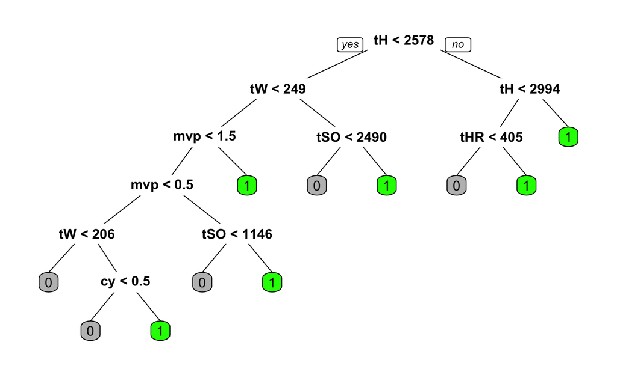

```r
library(rpart.plot)
rpart.plot(mod, box.col = ifelse(mod$frame$yval == 1, 'grey', 'green'))
```

## 結果驗證：`confusion table`

```r
candidates <- mutate(candidates, y.hat = predict(mod, type="class"), induct.prob = predict(mod)[,2])
confusion = tally(y.hat ~ inducted, data=candidates, format="count")
confusion
```

```
##      inducted
## y.hat   0   1
##     0 966  46
##     1  14  70
```

```r
sum(diag(confusion)) / sum(confusion)
```

```
## [1] 0.9452555
```

## Ｑ＆Ａ

## 參考資料

- [Building a Hall of Fame Classifier](https://baseballwithr.wordpress.com/2014/11/18/building-a-hall-of-fame-classifier-2/)
- [rpart.plot](http://www.milbo.org/rpart-plot/)